# Assignment - Week 03

Flurin Schindele

2026-03-07

```r
suppressPackageStartupMessages({
  library(AnnotationHub)
  library(Rsubread) # read alignment
  library(rtracklayer) # read/write genomic file formats
  library(Biostrings) # handling sequences
  library(Rfastp) # read QC/trimming
  library(epiwraps)
})
ah <- AnnotationHub()
```

```r
force_rerun <- TRUE
```

# Processing of ChIP-seq data

## Downloading Drosophila ChIP-seq data

The raw reads are downloaded from the ENCODE portal (accession ENCFF127RRR). The file is only downloaded if it does not already exist locally.

```r
dir.create("data")
dir.create("data/raw")
if (!file.exists("data/raw/ctcf.fastq.gz")) {
  download.file(
    url = "https://www.encodeproject.org/files/ENCFF127RRR/@@download/ENCFF127RRR.fastq.gz",
    destfile = "data/raw/ctcf.fastq.gz",
    mode = "wb"
  )
} else {
  print("File already exists. Skipping download...")
}
```

```
## [1] "File already exists. Skipping download..."
```

## Quality control

`Rfastp` performs adapter trimming and quality filtering in a single step. It produces a trimmed FASTQ file alongside a JSON report object (`qc`) containing per-read statistics. The `qc` object is saved to disk so that the plots below can be rendered even when this step is skipped on re-runs.

```r
if (force_rerun || !file.exists("data/raw/trimmed_ctcf_R1.fastq.gz")) {
  qc <- Rfastp::rfastp(
    read1 = "data/raw/ctcf.fastq.gz",
    outputFastq = "data/raw/trimmed_ctcf",
    adapterTrimming = TRUE,
    overrepresentationAnalysis = TRUE,
    thread = 4
  )
  saveRDS(qc, "data/raw/trimmed_ctcf_qc.rds")
} else {
  message("Trimmed reads already exist. Loading cached QC stats.")
  qc <- readRDS("data/raw/trimmed_ctcf_qc.rds")
}
```

The quality curves show per-base quality scores and nucleotide composition before and after trimming. We have short reads with rather low base quality over all positions but especially towards the end.

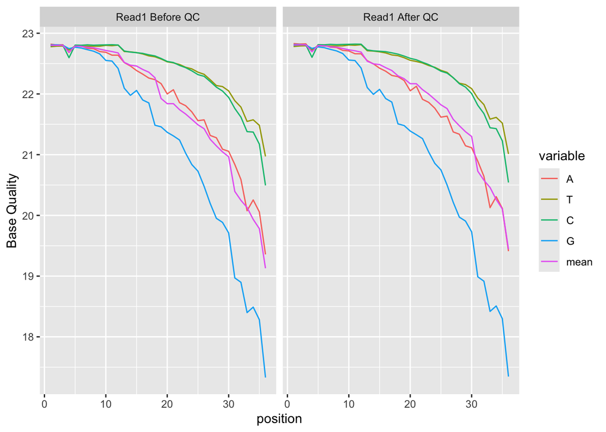

```r
Rfastp::curvePlot(qc, curves = "quality_curves")
```

QC content looks good and duplication levels are also acceptable. Also, `Rfastp` did not find any adapter sequences present in the reads.

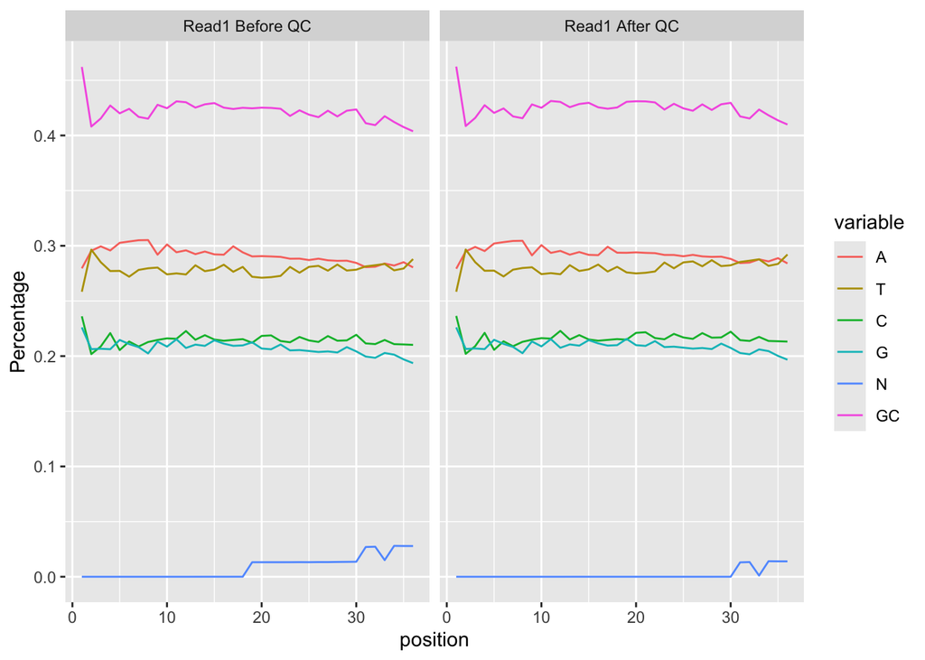

```r
Rfastp::curvePlot(qc, curve = "content_curves")
```

The duplication histogram shows how many reads appear at each duplication level. High duplication levels could indicate PCR over-amplification and potential loss of library complexity but here the distribution looks very good.

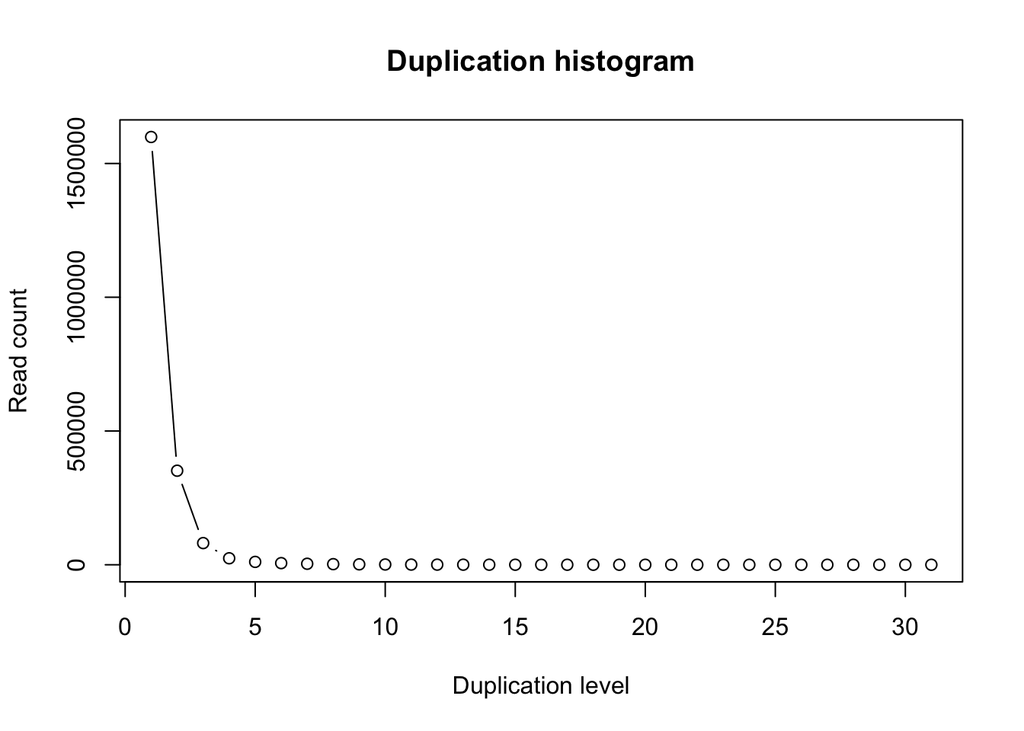

```r
plot(qc$duplication$histogram,
  type = "b",
  xlab = "Duplication level",
  ylab = "Read count",
  main = "Duplication histogram"
)
```

## Alignment of reads

Before alignment, we need to fetch the *D. melanogaster* BDGP6 genome sequence and build a genome index from the FASTA file. (The soft-masked version is used, meaning repetitive and low-complexity regions are represented in lowercase letters rather than being replaced with `N` (hard-masking). This allows the aligner to down-weight alignments in repetitive regions while still retaining the underlying sequence information.)

```r
if (force_rerun || !file.exists("data/BDGP6_genome/bdgp6.fasta.gz")) {
  dir.create("data/BDGP6_genome", showWarnings = FALSE)

  query_results <- query(
    ah,
    c("drosophila melanogaster", "BDGP6", "dna_sm", "2bit")
  )

  dm_genome <- ah[[tail(rev(query_results$ah_id)[1])]]

  export(import.2bit(dm_genome), "data/BDGP6_genome/bdgp6.fasta.gz", compress = TRUE)
} else {
  message("BDGP6 genome already exists. Skipping download.")
}
```

```
## loading from cache
```

```r
if (force_rerun || !file.exists("data/BDGP6_genome/rsubread.files")) {
  Rsubread::buildindex(
    "data/BDGP6_genome/rsubread",
    reference = "data/BDGP6_genome/bdgp6.fasta.gz"
  )
} else {
  message("Rsubread index already exists. Skipping index building.")
}
```

[output not shown]

[output cut: 26 more lines]

[output not shown]

Trimmed reads are aligned to the BDGP6 genome with `Rsubread::align`. The output is a coordinate-sorted BAM file. Alignment statistics are cached as an RDS file so the Report section can access them even when this step is skipped on re-runs.

```r
dir.create("data/aligned", showWarnings = FALSE)

if (force_rerun || !file.exists("data/aligned/ctcf.bam")) {
  align_stats <- Rsubread::align(
    index = "data/BDGP6_genome/rsubread", type = "dna",
    readfile1 = "data/raw/trimmed_ctcf_R1.fastq.gz",
    output_file = "data/aligned/ctcf.bam",
    sortReadsByCoordinates = TRUE,
    nthreads = 6
  )
  saveRDS(align_stats, "data/aligned/align_stats.rds")
} else {
  message("Aligned BAM already exists. Loading cached alignment stats.")
  align_stats <- readRDS("data/aligned/align_stats.rds")
}
```

[output not shown]

[output cut: 26 more lines]

```
##
## //================================   Summary =================================\\
## ||                                                                            ||
## ||                 Total reads : 3,816,990                                    ||
## ||                      Mapped : 3,505,377 (91.8%)                            ||
## ||             Uniquely mapped : 3,048,961                                    ||
## ||               Multi-mapping : 456,416                                      ||
## ||                                                                            ||
## ||                    Unmapped : 311,613                                      ||
## ||                                                                            ||
## ||                      Indels : 1,835                                        ||
## ||                                                                            ||
## ||                Running time : 4.6 minutes                                  ||
## ||                                                                            ||
## \\============================================================================//
```

```r
align_stats
```

```
##                       ctcf.bam
## Total_reads            3816990
## Mapped_reads           3505377
## Uniquely_mapped_reads  3048961
## Multi_mapping_reads     456416
## Unmapped_reads          311613
## Indels                    1835
```

Enriched genomic regions (peaks) are called from the aligned BAM using MACS3. The Drosophila effective genome size (`gsize = "dm"`) is used for the statistical model.

```r
dir.create("data/peaks", showWarnings = FALSE)

if (!require("MACSr", quietly = TRUE)) BiocManager::install("MACSr")
library(MACSr)

if (force_rerun || !file.exists("data/peaks/ctcf_peaks.narrowPeak")) {
  callpeak(
    tfile = "data/aligned/ctcf.bam",
    gsize = "dm",
    outdir = "data/peaks",
    name = "ctcf"
  )
} else {
  message("Peaks file already exists. Skipping peak calling.")
}
```

[output not shown]

```
## macsList class
## $outputs:
##  data/peaks/ctcf_model.r
##  data/peaks/ctcf_peaks.narrowPeak
##  data/peaks/ctcf_peaks.xls
##  data/peaks/ctcf_summits.bed
## $arguments: tfile, gsize, outdir, name
## $log:
##  INFO  @ 12 Mar 2026 10:00:33: [2453 MB]
##  # Command line:
##  # ARGUMENTS LIST:
##  # name = ctcf
##  # format = AUTO
## ...
```

```r
peaks <- rtracklayer::import("data/peaks/ctcf_peaks.narrowPeak", format = "narrowPeak")
peaks <- peaks[order(peaks$score, decreasing = TRUE)]
head(peaks)
```

```
## GRanges object with 6 ranges and 6 metadata columns:
##       seqnames            ranges strand |           name     score signalValue
##          <Rle>         <IRanges>  <Rle> |    <character> <numeric>   <numeric>
##   [1]        X   8676729-8677168      * | ctcf_peak_4754      3479     26.6893
##   [2]       3L   2466484-2466943      * | ctcf_peak_2341      3473     27.2409
##   [3]        X   7241908-7242410      * | ctcf_peak_4701      3468     28.2879
##   [4]       2L 14094545-14095065      * |  ctcf_peak_950      3462     25.3319
##   [5]       3L 21652793-21653244      * | ctcf_peak_3089      3431     24.7560
##   [6]       3R 24556909-24557327      * | ctcf_peak_4081      3431     27.8630
##          pValue    qValue      peak
##       <numeric> <numeric> <integer>
##   [1]   356.114   347.957       213
##   [2]   355.219   347.364       220
##   [3]   353.800   346.848       199
##   [4]   352.992   346.267       236
##   [5]   349.415   343.133       199
##   [6]   349.462   343.175       190
##   -------
##   seqinfo: 298 sequences from an unspecified genome; no seqlengths
```

## Report

1. After filtering by `Rfastp`, we have 3816990 reads left for alignment. Of those, **3505377** were successfully mapped to the reference genome, which corresponds to a mapping rate of **91.84%**.
2. We identified **5405** peaks in the ChIP-seq data, which are potential binding sites of the CTCF transcription factor in the Drosophila genome.

### Signal around a peak inside a gene

To check what peaks fall inside gene bodies, we first load the latest Ensembl BDGP6 gene annotation from AnnotationHub. We also need to harmonise Chromosome naming conventions between the annotation and the peaks object, then peaks are subset to those overlapping a gene body.

```r
query_results <- query(ah, c("Drosophila melanogaster", "EnsDb", "BDGP6"))
dm_ensdb <- ah[[tail(query_results$ah_id, 1)]]
```

```
## loading from cache
```

```
## require("ensembldb")
```

```r
genes <- genes(dm_ensdb)
seqlevelsStyle(genes) <- seqlevelsStyle(peaks) # harmonise chr naming
peaks_in_genes <- suppressWarnings(peaks[overlapsAny(peaks, genes, type = "within")])
```

The signal track below shows read coverage from the CTCF ChIP-seq experiment around a intragenic peak, extended by 1 kb on each side. The gene model is shown below the coverage track.

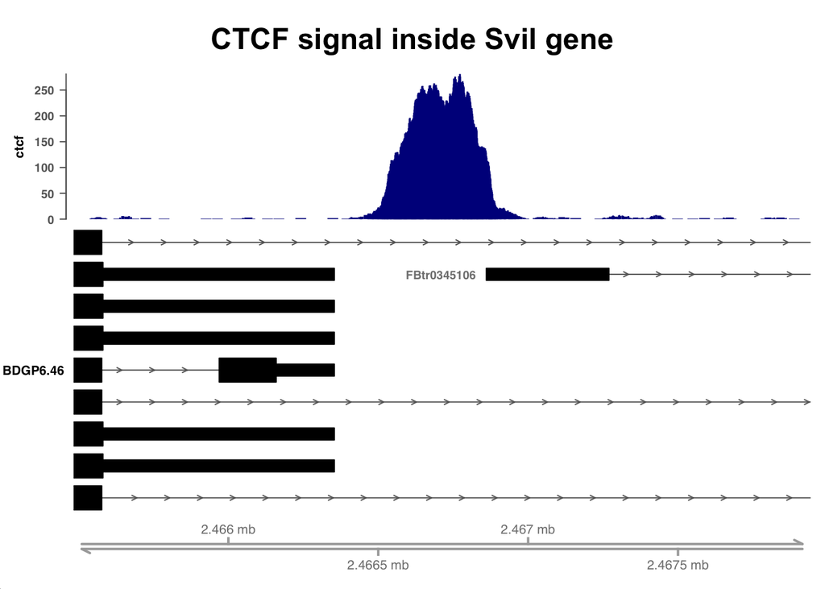

```r
region_of_interest <- peaks_in_genes[1]

overlapping_gene <- suppressWarnings(genes[overlapsAny(genes, region_of_interest, , type = "any")][1]$gene_name)

plotSignalTracks(
  list(ctcf = "data/aligned/ctcf.bam"),
  region = region_of_interest,
  extend = 1000,
  genomeAxis = TRUE,
  ensdb = dm_ensdb,
  transcripts = "full",
  main = paste0("CTCF signal inside ", overlapping_gene, " gene"),
  cex.main = 1.5
)
```

The BAM file is converted to a bigWig coverage track using `bam2bw`. Reads are extended to 176 bp (estimated fragment length by MACS3) before computing coverage.

```r
dir.create("data/coverage_tracks", showWarnings = FALSE)

if (force_rerun || !file.exists("data/coverage_tracks/ctcf.bw")) {
  bam2bw(
    bamfile = "data/aligned/ctcf.bam",
    output_bw = "data/coverage_tracks/ctcf.bw",
    extend = 176)
} else {
  message("Coverage track already exists. Skipping bam2bw.")
}
```

```
## `paired` not specified, assuming single-end reads. Set to paired='auto' to automatically detect.
```

```
## Reading in signal...
```

```
## Writing bigwig...
```

A signal matrix is computed centred on the top 200 peaks (ranked by MACS3 score), extended by ±1 kb. The heatmap visualises ChIP-seq enrichment across all selected peaks, with each row representing one peak. Here we can see, that the peaks are quite narrow and show a strong enrichment at the center.

```r
sm <- signal2Matrix(
  list(ctcf = "data/coverage_tracks/ctcf.bw"),
  regions = peaks[1:200],
  extend = 1000
)
```

```
## Reading data/coverage_tracks/ctcf.bw
```

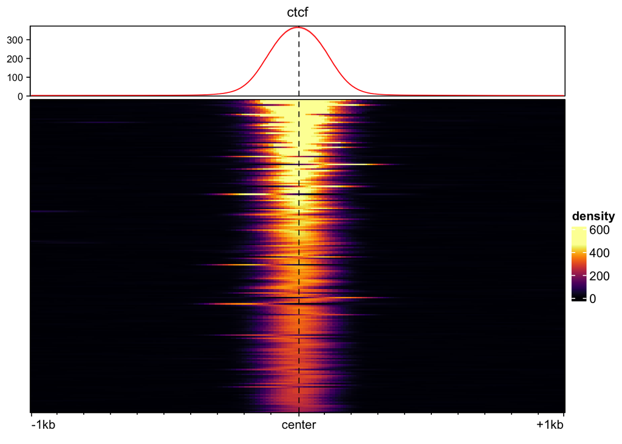

```r
plotEnrichedHeatmaps(sm)
```